# Homework 8

Lawson Busch

11/11/2018

# Packages and Data

```r
library(ggplot2)
library(dplyr)
library(ISLR)
library(MASS)
library(glmnet)
library(boot)
library(pROC)
data(Smarket)

# See the codebook
?Smarket
```

# Excercises

## Excercise 1

```r
train <- Smarket %>%
  filter(Year != 2005)

test <- Smarket %>%
  filter(Year == 2005)
```

## Excersise 2

### 2a)

To get the number of days of stock market data for each year in our training data set:

```r
train_days <- train %>%
  group_by(Year) %>%
  summarize(days = n())

head(train_days)
```

```
## # A tibble: 4 x 2
##    Year  days
##   <dbl> <int>
## 1  2001   242
## 2  2002   252
## 3  2003   252
## 4  2004   252
```

### 2b)

To get the greatest observed loss (for a given day):

```r
dplyr::filter(train, Today == min(Today))
```

```
##   Year  Lag1   Lag2   Lag3   Lag4   Lag5 Volume  Today Direction
## 1 2001 0.623 -1.864 -2.239 -0.106 -0.056 1.2766 -4.922      Down
```

Or that the greatest observed loss is -4.922.

To get the greatest observed gain (for a given day):

```r
dplyr::filter(train, Today == max(Today))
```

```
##   Year   Lag1   Lag2   Lag3   Lag4  Lag5  Volume Today Direction
## 1 2002 -2.702 -3.291 -3.835 -2.702 0.566 2.44102 5.733        Up
```

From the above we can see that the greatest observed gain is 5.733.

To get the percentage of the days that the stocks went “Up”:

```r
nrow(dplyr::filter(train, Direction == "Up")) / nrow(train)
```

```
## [1] 0.508016
```

Or that the stocks went “Up” on approximately 50% of days.

### 2c)

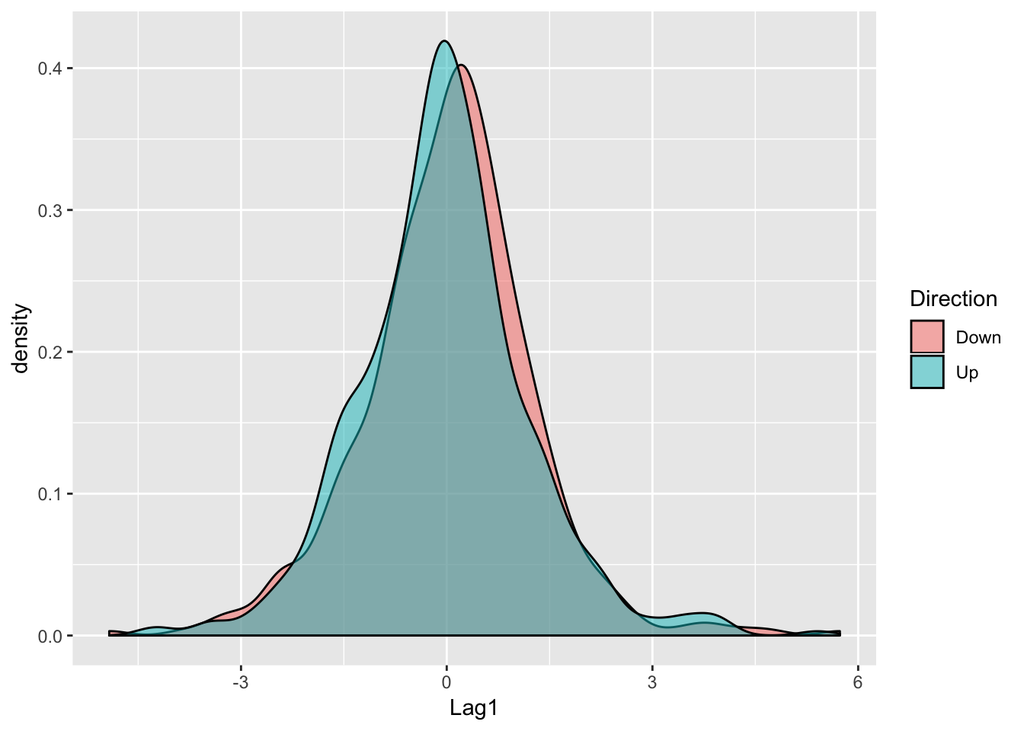

```r
ggplot(train, aes(x = Lag1, fill = Direction)) + geom_density(alpha = 0.5)
```

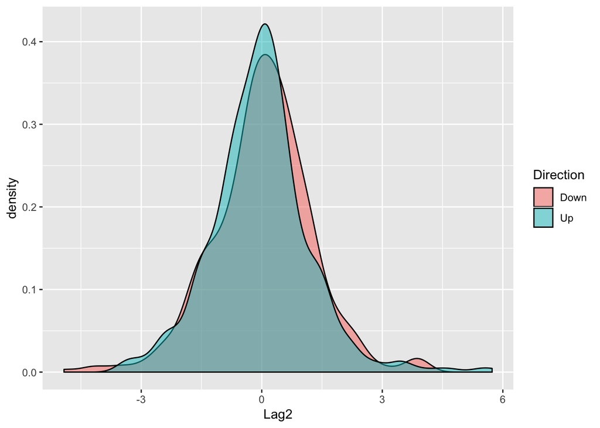

```r
ggplot(train, aes(x = Lag2, fill = Direction)) + geom_density(alpha = 0.5)
```

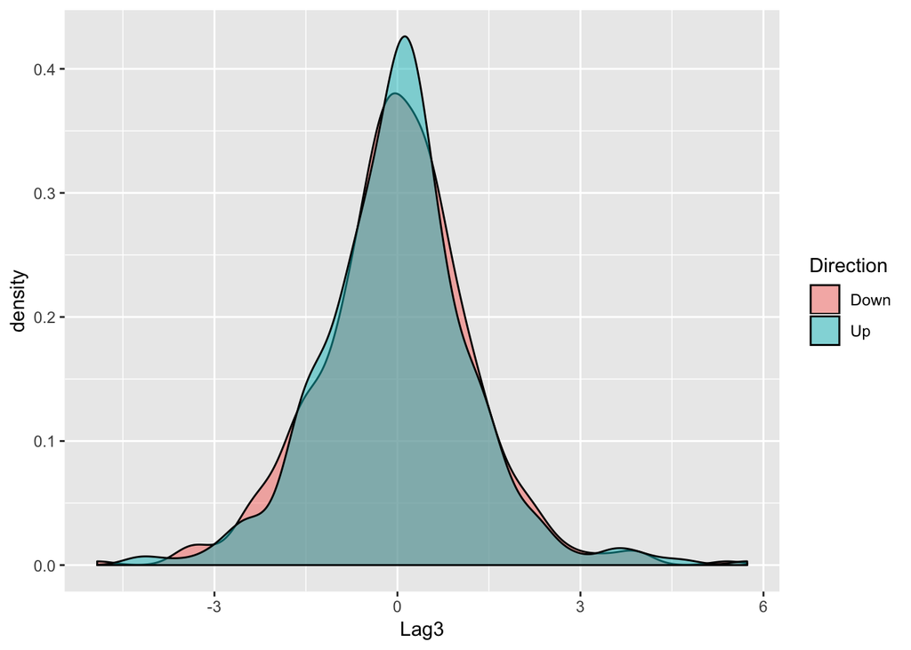

```r
ggplot(train, aes(x = Lag3, fill = Direction)) + geom_density(alpha = 0.5)
```

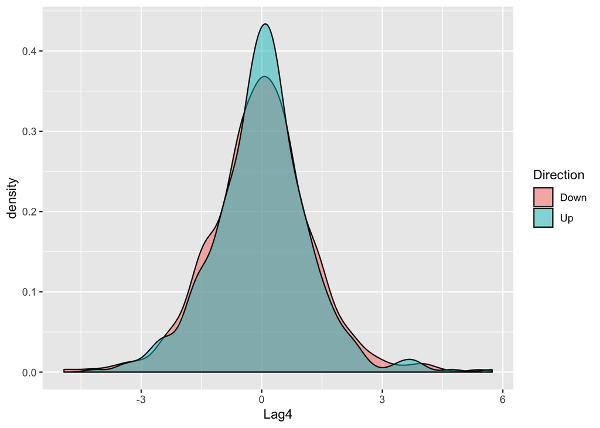

```r
ggplot(train, aes(x = Lag4, fill = Direction)) + geom_density(alpha = 0.5)
```

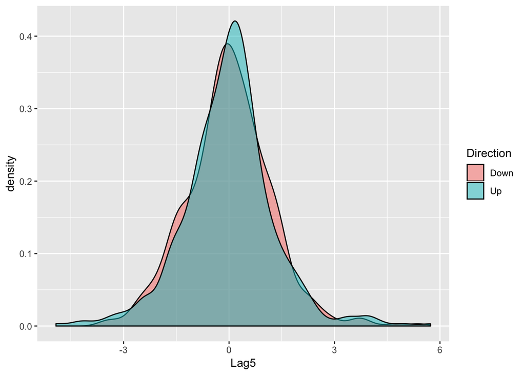

```r
ggplot(train, aes(x = Lag5, fill = Direction)) + geom_density(alpha = 0.5)
```

### 2d)

```r
run_lengths <- data.frame(lengths = rle(as.numeric(train$Direction))$length)
```

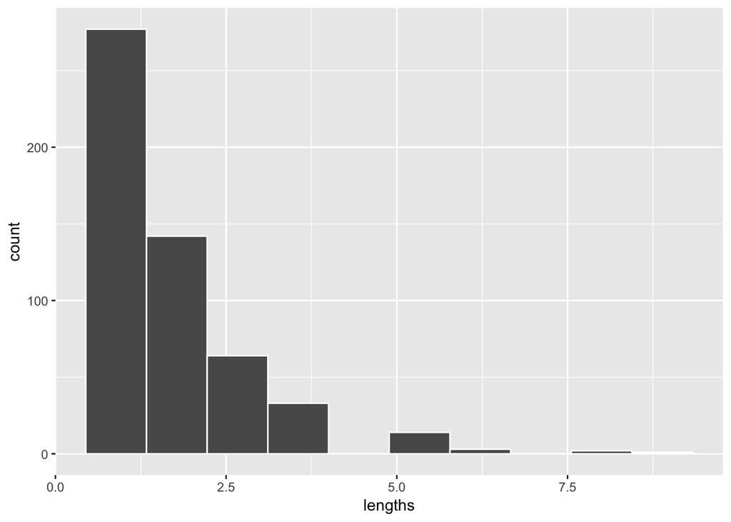

```r
ggplot(run_lengths, aes(x = lengths)) + geom_histogram(bins = 10, color = "white")
```

From the above plot, we can see that by far the most common run is 1 day, which is essentially no run. We can see that runs of 2, 3, and even 4 days are fairly common, but decrease with each increase in days. We can also see that runs longer than 4 days are virtually nonexistant.

## Excercise 3

### 3a)

Both Logistic Regression and QDA are valid techniques because Direction is a binomial factor. This means that we can use Logistic Regression, because Direction is binomial, and QDA is applicable to binomial factors as well.

### 3b)

```r
log_1 <- glm(factor(Direction) ~ Lag1 + Lag2 + Lag3 + Lag4 + Lag5, train, family="binomial")
qda_1 <- qda(Direction ~ Lag1 + Lag2 + Lag3 + Lag4 + Lag5, data = train)
summary(log_1)
```

```
##
## Call:
## glm(formula = factor(Direction) ~ Lag1 + Lag2 + Lag3 + Lag4 +
##     Lag5, family = "binomial", data = train)
##
## Deviance Residuals:
##    Min      1Q  Median      3Q     Max
## -1.339  -1.189   1.070   1.163   1.326
##
## Coefficients:
##              Estimate Std. Error z value Pr(>|z|)
## (Intercept)  0.032269   0.063379   0.509    0.611
## Lag1        -0.055510   0.051706  -1.074    0.283
## Lag2        -0.044218   0.051681  -0.856    0.392
## Lag3         0.008918   0.051517   0.173    0.863
## Lag4         0.008556   0.051514   0.166    0.868
## Lag5        -0.003243   0.051089  -0.063    0.949
##
## (Dispersion parameter for binomial family taken to be 1)
##
##     Null deviance: 1383.3  on 997  degrees of freedom
## Residual deviance: 1381.3  on 992  degrees of freedom
## AIC: 1393.3
##
## Number of Fisher Scoring iterations: 3
```

```r
summary(qda_1)
```

```
##         Length Class  Mode
## prior    2     -none- numeric
## counts   2     -none- numeric
## means   10     -none- numeric
## scaling 50     -none- numeric
## ldet     2     -none- numeric
## lev      2     -none- character
## N        1     -none- numeric
## call     3     -none- call
## terms    3     terms  call
## xlevels  0     -none- list
```

### 3c)

```r
log_l1 <- glm(factor(Direction) ~ Lag1, train, family="binomial")
log_l2 <- glm(factor(Direction) ~ Lag2, train, family="binomial")
log_l3 <- glm(factor(Direction) ~ Lag3, train, family="binomial")
log_l4 <- glm(factor(Direction) ~ Lag4, train, family="binomial")
log_l5 <- glm(factor(Direction) ~ Lag5, train, family="binomial")
```

```r
# Store the true classes of the cases
true_Direction <- test$Direction

# Calculate the probability predictions for each case
prob_pred  <- predict(log_l1, newdata = test, type = "response")

# Summarize the quality of these classifications using 0.5 cut-off
tab <- table(true_Direction, prob_pred >= 0.5)

sum(diag(tab)/sum(tab))
```

```
## [1] 0.5396825
```

```r
# Calculate the probability predictions for each case
prob_pred  <- predict(log_l2, newdata = test, type = "response")

# Summarize the quality of these classifications using 0.5 cut-off
tab <- table(true_Direction, prob_pred >= 0.5)

sum(diag(tab)/sum(tab))
```

```
## [1] 0.5912698
```

```r
# Calculate the probability predictions for each case
prob_pred  <- predict(log_l3, newdata = test, type = "response")

# Summarize the quality of these classifications using 0.5 cut-off
tab <- table(true_Direction, prob_pred >= 0.5)

sum(diag(tab)/sum(tab))
```

```
## [1] 0.4404762
```

```r
# Calculate the probability predictions for each case
prob_pred  <- predict(log_l4, newdata = test, type = "response")

# Summarize the quality of these classifications using 0.5 cut-off
tab <- table(true_Direction, prob_pred >= 0.5)

sum(diag(tab)/sum(tab))
```

```
## [1] 0.4404762
```

```r
# Calculate the probability predictions for each case
prob_pred  <- predict(log_l5, newdata = test, type = "response")

# Summarize the quality of these classifications using 0.5 cut-off
tab <- table(true_Direction, prob_pred >= 0.5)

sum(diag(tab)/sum(tab))
```

```
## [1] 0.4404762
```

To find the best two “Lag” predictors, I made a logistic regression model for each individual “Lag” predictor using the training data set. I then used to the test data set to calculate their predictions and test for overall accuracy of these predictions. From the above calculations, it is clear that “Lag1” model (54% accuracy) and the “Lag2” model (59% accuracy) provide the best predictions. Thus, I concluded that the best two predictors are the “Lag1” and “Lag2” predictors.

### 3d)

```r
log_2 <- glm(factor(Direction) ~ Lag1 + Lag2, train, family="binomial")
qda_2 <- qda(Direction ~ Lag1 + Lag2, data = train)
summary(log_2)
```

```
##
## Call:
## glm(formula = factor(Direction) ~ Lag1 + Lag2, family = "binomial",
##     data = train)
##
## Deviance Residuals:
##    Min      1Q  Median      3Q     Max
## -1.345  -1.188   1.074   1.164   1.326
##
## Coefficients:
##             Estimate Std. Error z value Pr(>|z|)
## (Intercept)  0.03222    0.06338   0.508    0.611
## Lag1        -0.05562    0.05171  -1.076    0.282
## Lag2        -0.04449    0.05166  -0.861    0.389
##
## (Dispersion parameter for binomial family taken to be 1)
##
##     Null deviance: 1383.3  on 997  degrees of freedom
## Residual deviance: 1381.4  on 995  degrees of freedom
## AIC: 1387.4
##
## Number of Fisher Scoring iterations: 3
```

```r
summary(qda_2)
```

```
##         Length Class  Mode
## prior   2      -none- numeric
## counts  2      -none- numeric
## means   4      -none- numeric
## scaling 8      -none- numeric
## ldet    2      -none- numeric
## lev     2      -none- character
## N       1      -none- numeric
## call    3      -none- call
## terms   3      terms  call
## xlevels 0      -none- list
```

### 3e)

```r
exp(-0.05562)
```

```
## [1] 0.9458985
```

```r
exp(-0.04449)
```

```
## [1] 0.9564852
```

To intepret these coefficients, it is best to convert them from log(odds) for to odds form. Currently, we can see that for every unit increase in “Lag1”, the log(odds) of the market being “Up” decrease by 0.05562, and for every unit increase in “Lag2”, the log(odds) of the market being “Up” decrease by -0.04449. If we exponentiate, we can see that for every unit increase in “Lag1”, the odds of the market being “Up” decrease by a multiplicative factor of 0.9458985, and for every unit increase in “Lag2”, the odds of the market being “Up” decrease by a multiplicative factor of 0.9564852.

## Excercise 4

### 4a)

```r
predict_data = data.frame(Lag1=2.0, Lag2=-2.0, Lag3=-4.0, Lag4=1.0, Lag5=2.0)
```

To predict using all five Lags:

```r
# Calculate the probability predictions for each case
prob_pred  <- predict(log_1, newdata = predict_data, type = "response")

prob = exp(prob_pred)/(1 + exp(prob_pred))
prob
```

```
##         1
## 0.6210532
```

```r
# Calculate the probability predictions for each case
prob_pred  <- predict(qda_1, newdata = predict_data, type = "response")
prob_pred
```

```
## $class
## [1] Down
## Levels: Down Up
##
## $posterior
##        Down        Up
## 1 0.7096266 0.2903734
```

To predict using Lag1 and Lag2:

```r
# Calculate the probability predictions for each case
prob_pred  <- predict(log_2, newdata = predict_data, type = "response")

prob = exp(prob_pred)/(1 + exp(prob_pred))
prob
```

```
##         1
## 0.6230436
```

```r
prob_pred  <- predict(qda_2, newdata = predict_data, type = "response")
prob_pred
```

```
## $class
## [1] Down
## Levels: Down Up
##
## $posterior
##        Down        Up
## 1 0.5067301 0.4932699
```

## Excercise 5

### 5a)

```r
direction <- train$Direction
roc(response = direction, pred = log_1$fitted, plot = TRUE, legacy.axes = TRUE)
```

```
##
## Call:
## roc.default(response = direction, predictor = log_1$fitted, plot = TRUE,     legacy.axes = TRUE)
##
## Data: log_1$fitted in 491 controls (direction Down) < 507 cases (direction Up).
## Area under the curve: 0.5265
```

```r
roc(response = direction, pred = log_2$fitted, plot = TRUE, legacy.axes = TRUE, add = TRUE, col = 2) #red
```

```
##
## Call:
## roc.default(response = direction, predictor = log_2$fitted, plot = TRUE,     legacy.axes = TRUE, add = TRUE, col = 2)
##
## Data: log_2$fitted in 491 controls (direction Down) < 507 cases (direction Up).
## Area under the curve: 0.5267
```

```r
roc(response = direction, pred = predict(qda_1, newdata = train)$posterior[,2], plot = TRUE, legacy.axes = TRUE, add = TRUE, col = 3) #green
```

```
##
## Call:
## roc.default(response = direction, predictor = predict(qda_1,     newdata = train)$posterior[, 2], plot = TRUE, legacy.axes = TRUE,     add = TRUE, col = 3)
##
## Data: predict(qda_1, newdata = train)$posterior[, 2] in 491 controls (direction Down) < 507 cases (direction Up).
## Area under the curve: 0.5655
```

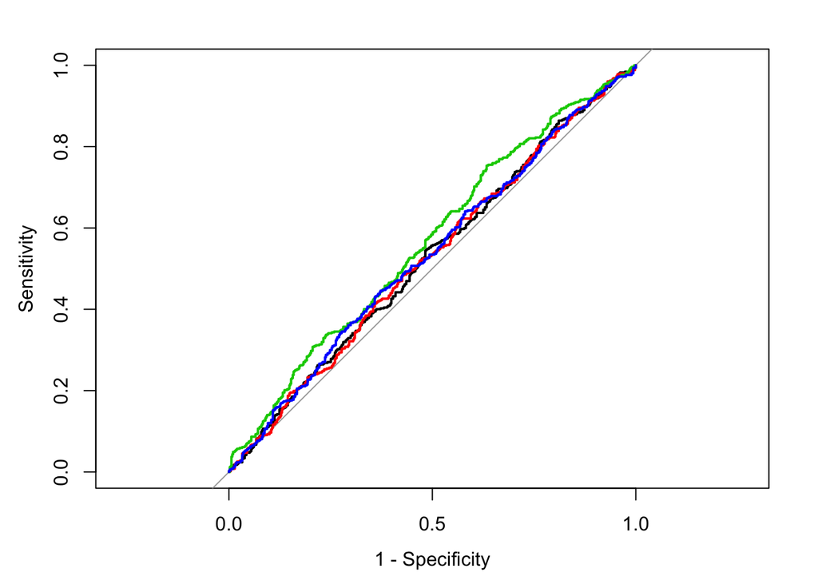

```
##
## Call:
## roc.default(response = direction, predictor = predict(qda_2,     newdata = train)$posterior[, 2], plot = TRUE, legacy.axes = TRUE,     add = TRUE, col = 4)
##
## Data: predict(qda_2, newdata = train)$posterior[, 2] in 491 controls (direction Down) < 507 cases (direction Up).
## Area under the curve: 0.5337
```

```r
roc(response = direction, pred = predict(qda_2, newdata = train)$posterior[,2], plot = TRUE, legacy.axes = TRUE, add = TRUE, col = 4) #blue
```

### 5b)

To classify the direction for the first logistic model:

```r
# Calculate the probability predictions for each case
prob_pred  <- predict(log_1, newdata = test, type = "response")

# Summarize the quality of these classifications using 0.5 cut-off
tab <- table(true_Direction, prob_pred >= 0.5)
prop.table(tab, margin = 1)
```

```
##
## true_Direction     FALSE      TRUE
##           Down 0.3333333 0.6666667
##           Up   0.2127660 0.7872340
```

```r
sum(diag(tab)/sum(tab))
```

```
## [1] 0.5873016
```

From the above, we can see that the sensitivity is approximately 0.78, the specificity is 0.33, and the overall accuracy for this model is approximately 0.59 for the log_1 model.

To classify the direction for the second logistic model:

```r
# Calculate the probability predictions for each case
prob_pred  <- predict(log_2, newdata = test, type = "response")

# Summarize the quality of these classifications using 0.5 cut-off
tab <- table(true_Direction, prob_pred >= 0.5)
prop.table(tab, margin = 1)
```

```
##
## true_Direction     FALSE      TRUE
##           Down 0.3153153 0.6846847
##           Up   0.2482270 0.7517730
```

```r
sum(diag(tab)/sum(tab))
```

```
## [1] 0.5595238
```

From the above, we can see that the sensitivity is approximately 0.75, the specificity is 0.31, and the overall accuracy for this model is approximately 0.56 for the log_2 model.

To classify the direction for the first quadratic model:

```r
# Calculate the probability predictions for each case
prob_pred  <- predict(qda_1, newdata = test, type = "response")$posterior[,2]

# Summarize the quality of these classifications using 0.5 cut-off
tab <- table(true_Direction, prob_pred >= 0.5)
prop.table(tab, margin = 1)
```

```
##
## true_Direction     FALSE      TRUE
##           Down 0.3333333 0.6666667
##           Up   0.2482270 0.7517730
```

```r
sum(diag(tab)/sum(tab))
```

```
## [1] 0.5674603
```

From the above, we can see that the sensitivity is approximately 0.75, the specificity is 0.33, and the overall accuracy for this model is approximately 0.57 for the qda_1 model.

To classify the direction for the second quadratic model:

```r
# Calculate the probability predictions for each case
prob_pred  <- predict(qda_2, newdata = test, type = "response")$posterior[,2]

# Summarize the quality of these classifications using 0.5 cut-off
tab <- table(true_Direction, prob_pred >= 0.5)
prop.table(tab, margin = 1)
```

```
##
## true_Direction     FALSE      TRUE
##           Down 0.2702703 0.7297297
##           Up   0.1418440 0.8581560
```

```r
sum(diag(tab)/sum(tab))
```

```
## [1] 0.5992063
```

From the above, we can see that the sensitivity is approximately 0.86, the specificity is 0.27, and the overall accuracy for this model is approximately 0.6 for the qda_2 model.

### 5c)

In light of the above calculations, I would say that the qda_2 model provides the best classifications for market behavior. This is due to the fact that it correctly picks 86% of the days that the market will go “Up” and has an overall accuracy rate of 60%. However, I would say that if we care more apout the specificity of our model, I would choose log_1, as it predicts “Down” days significantly better than the qda_2 model (33% accuracy compared to 27% accuracy, respectively), while having a comparable overall accuracy rate of 59%.

However, it should be noted that none of these classification models are that much better than just flipping a coin. If we flipped a coin for up or down, our prediction should be accurate 50% of the time, and our best models only have an accuracy rate of 59-60%, which is not much better. Further, if we look at the ROC curve plot, all of the model’s lines lie close to the strait grey line indicated a coin flip, visually demonstrating that our models are not really that much better than flipping a coin.